# Data Acquisition and Survey Methods

Group 10

# Exercise habits and their impact on students’ focus

Group 10 investigates whether students’ physical exercise habits are related to their reported level of mental brain fog during lectures. The original proposal referred to exercise frequency and academic confidence. In the final survey data, the available Group 10 variables are exercise minutes, preferred exercise type, and brain fog. Therefore, the analysis below focuses on these measured variables.

## Table of contents

1. Load data
2. Survey questions and variables
3. Research questions and hypotheses
4. Exploratory data analysis
5. Descriptive inference
6. Analytic inference
7. Functions used
8. Conclusion

## Load data

```r
library(tidyverse)
library(kableExtra)
```

```r
# Full dataset
total_survey <- read_csv("Survey_results_2026.csv", show_col_types = FALSE)

# Only Group 10 data
survey <- total_survey %>%
  select(
    starts_with("DQ"),
    starts_with("G10")
  )

# Remove strings
names(survey) <- names(survey) %>%
  str_remove("^DQ\\s*") %>%
  str_remove("^G10\\s*")

# Rename columns
survey <- survey %>%
  rename(
    age = 1,
    gender = 2,
    academic_program = 3,
    exercise_minutes = 4,
    exercise_type = 5,
    brain_fog = 6
  )

# Factorize and create new variables
survey <- survey %>%
  mutate(
    age = factor(age, levels = c("18-20", "21-23", "23-25", "25-30", "30-35", "over 35"), ordered = TRUE),
    exercise_type = as.factor(exercise_type),
    gender = as.factor(gender),
    academic_program = as.factor(academic_program),
    intensity_level = case_when(
      exercise_type %in% c("Weightlifting", "Cardio", "Team Sports") ~ "High-intensity",
      exercise_type == "Yoga/Flexibility" ~ "Low-intensity",
      TRUE ~ NA_character_
    ),
    intensity_level = factor(intensity_level, levels = c("Low-intensity", "High-intensity"))
  )
```

## Survey questions and variables

The analysis is based on the mandatory demographic questions and the three Group 10 survey questions.

[output not shown]

## Research questions and hypotheses

**RQ1:** Do students who complete more minutes of physical exercise report lower levels of brain fog during lectures?  
**Hypothesis:** Exercise minutes and brain fog are negatively associated.

**RQ2:** Does high-intensity training (e.g., gym, running) correlate with higher academic confidence compared to low-intensity (e.g., walking)?  
**Hypothesis:** Students preferring high-intensity training report lower brain fog (as a proxy for higher academic confidence) than those preferring low-intensity training.

**RQ3:** Is age negatively associated with the number of minutes spent on physical exercise per week?  
**Hypothesis:** Older students report fewer exercise minutes.

## Exploratory data analysis

The exploratory analysis uses one visualization for each research question. The plots include both quantitative and categorical variables and help identify patterns before formal hypothesis testing.

### RQ1: Exercise minutes and brain fog

We built a layered data visualization using the `ggplot2` package to analyze how weekly exercise minutes vary across different levels of brain fog. We started by initializing the plot with the `ggplot` function, mapping the `survey` dataset. Inside the global aesthetics, we converted the `brain_fog` variable into a discrete factor so R would treat it as a categorical x-axis with five distinct groups, placed `exercise_minutes` on the continuous y-axis, and set the box colors to change dynamically based on the brain fog level.

To visualize the distribution, we overlaid two distinct geometric layers. The first layer uses `geom_boxplot` to construct the standard boxplots showing the median, quartiles, and whiskers for each category. We set the transparency to 0.7 and explicitly hid the default outliers using `outlier.shape = NA` because we planned to show all raw data points instead. Directly on top of this, we added a `geom_jitter` layer to plot every individual response as a dot. By setting a jitter width of 0.15, we spread the dots out slightly horizontally so they wouldn’t stack invisibly on top of each other, and a 0.5 transparency allowed us to see data density through overlapping points.

Finally, we customized the appearance and context of the chart. We applied a custom color palette using `scale_fill_manual` to dye the boxes and named the legend “Brain fog”, while using `scale_color_manual` with the guide set to none to ensure the jittered dots matched the box colors without spawning a redundant second legend. We then used the `labs` function to give the plot a clear title and explicitly define our axes, ensuring the reader knows the y-axis tracks the last seven days of exercise and the x-axis spans from none to severe. The entire visual is wrapped in `theme_minimal()`, which strips away the default heavy grey grid lines to give the final plot a clean, professional aesthetic. The color scale is green for low brain fog and red for severe brain fog.

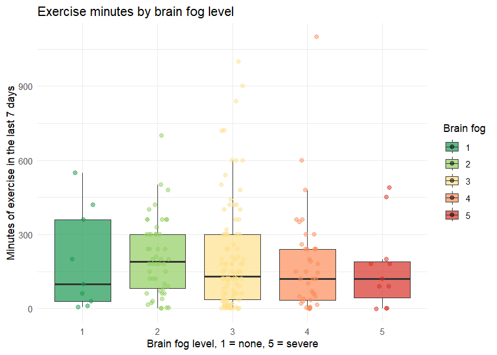

```r
ggplot(survey, aes(x = factor(brain_fog), y = exercise_minutes, fill = factor(brain_fog))) +
  geom_boxplot(alpha = 0.7, outlier.shape = NA) +
  geom_jitter(aes(color = factor(brain_fog)), width = 0.15, alpha = 0.5, size = 1.8) +
  scale_fill_manual(values = brain_fog_cols, name = "Brain fog") +
  scale_color_manual(values = brain_fog_cols, guide = "none") +
  labs(
    title = "Exercise minutes by brain fog level",
    x = "Brain fog level, 1 = none, 5 = severe",
    y = "Minutes of exercise in the last 7 days"
  ) +
  theme_minimal()
```

**Finding:**

To investigate our research question, we visualized the relationship between weekly physical activity and academic performance by plotting the quantitative variable of weekly exercise minutes against the ordinal categorical variable of reported brain fog levels using a combined boxplot and jittered scatter plot. Our initial hypothesis stated that exercise minutes and brain fog are negatively associated, meaning that higher levels of physical activity would correspond to lower levels of cognitive fatigue.

The empirical data, however, reveals a more nuanced, non linear relationship rather than a strict, steady downward trend. The central tendencies, indicated by the median lines, actually peak at a mild brain fog level of 2 (around 200 minutes) and show only a gradual decline through levels 3 and 4, while students reporting zero brain fog at level 1 display a surprisingly low median of approximately 100 minutes. Furthermore, the high variability and vertical spread within levels 1 through 3 including several highly active outliers in level 3 exercising up to 1,000 minutes demonstrate that moderate brain fog is common across a wide range of activity levels.

The hypothesis fails as a linear rule because high exercise does not automatically guarantee a clear mind.

### RQ2: Brain fog by exercise intensity

A boxplot is appropriate because the explanatory variable is categorical and the outcome variable is measured on a 1-5 scale. We grouped the exercise types into two intensity levels: High-intensity (Cardio, Weightlifting, Team Sports) and Low-intensity (Yoga/Flexibility).

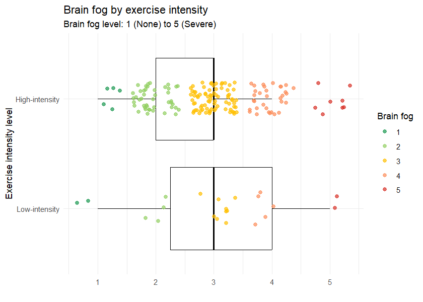

```r
ggplot(survey[!is.na(survey$intensity_level), ], aes(
  x = intensity_level,
  y = brain_fog,
  color = factor(brain_fog)
)) +
  geom_boxplot(color = "black", outlier.shape = NA) +
  geom_jitter(width = 0.15, alpha = 0.7, size = 1.8) +
  coord_flip() +
  scale_y_continuous(breaks = 1:5) +
  scale_color_manual(
    values = c(
      "1" = "#1a9850",  # dark green: no brain fog
      "2" = "#91cf60",  # light green
      "3" = "#ffbf00",  # yellow
      "4" = "#fc8d59",  # orange
      "5" = "#d73027"   # red: severe brain fog
    ),
    name = "Brain fog"
  ) +
  labs(
    title = "Brain fog by exercise intensity",
    subtitle = "Brain fog level: 1 (None) to 5 (Severe)",
    x = "Exercise intensity level",
    y = ""
  ) +
  theme_minimal()
```

**Finding:** The visualization reveals that the median brain fog level is identical (level 3) for both high-intensity and low-intensity exercise groups. However, the high-intensity group has a tighter and lower interquartile range (spanning levels 2 to 3) compared to the low-intensity group (which spans levels 2 to 4). This indicates that while the medians are the same, high-intensity exercise is descriptively associated with a slightly lower overall distribution of brain fog.

### RQ3: Age and exercise minutes

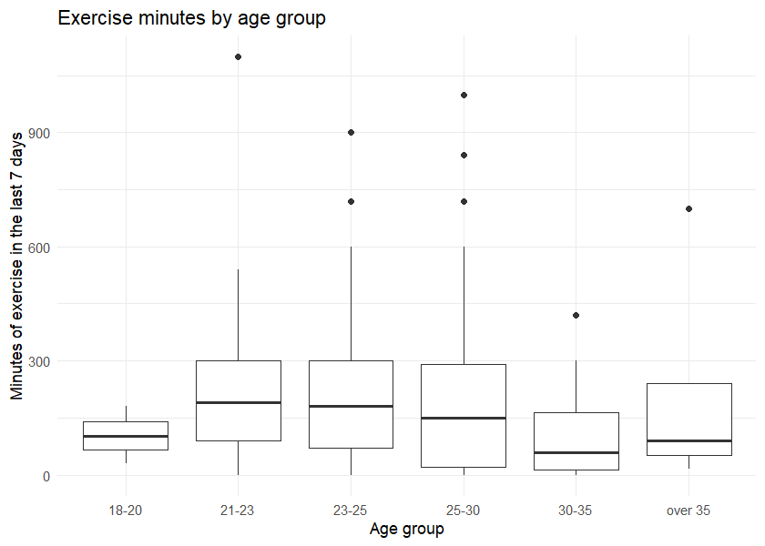

```r
ggplot(survey, aes(x = age, y = exercise_minutes)) +
  geom_boxplot() +
  labs(
    title = "Exercise minutes by age group",
    x = "Age group",
    y = "Minutes of exercise in the last 7 days"
  ) +
  theme_minimal()
```

## Descriptive inference

The following table summarizes the quantitative variables using sample size, mean, standard deviation, median, minimum, and maximum. The median is useful because exercise minutes may be right-skewed if some students report very high exercise times.

```r
# One combined descriptive summary table

numeric_vars <- survey %>%
  select(exercise_minutes, brain_fog)

numeric_summary <- data.frame(
  Variable = c("Exercise minutes", "Brain fog"),
  Type = "Quantitative",
  Category = "",
  N = as.character(sapply(numeric_vars, function(x) sum(!is.na(x)))),
  Percent = "",
  Mean = as.character(round(sapply(numeric_vars, function(x) mean(x, na.rm = TRUE)), 2)),
  SD = as.character(round(sapply(numeric_vars, function(x) sd(x, na.rm = TRUE)), 2)),
  Median = as.character(round(sapply(numeric_vars, function(x) median(x, na.rm = TRUE)), 2)),
  Min = as.character(round(sapply(numeric_vars, function(x) min(x, na.rm = TRUE)), 2)),
  Max = as.character(round(sapply(numeric_vars, function(x) max(x, na.rm = TRUE)), 2))
)

categorical_table <- function(data, variable, label) {
  data %>%
    filter(!is.na(.data[[variable]])) %>%
    count(.data[[variable]], name = "N") %>%
    mutate(
      Variable = label,
      Type = "Categorical",
      Category = as.character(.data[[variable]]),
      Percent = paste0(round(100 * N / sum(N), 1), "%"),
      Mean = "",
      SD = "",
      Median = "",
      Min = "",
      Max = "",
      N = as.character(N)
    ) %>%
    select(Variable, Type, Category, N, Percent, Mean, SD, Median, Min, Max)
}

categorical_summary <- bind_rows(
  categorical_table(survey, "age", "Age group"),
  categorical_table(survey, "gender", "Gender"),
  categorical_table(survey, "academic_program", "Academic program"),
  categorical_table(survey, "exercise_type", "Preferred exercise type"),
  categorical_table(survey, "intensity_level", "Exercise intensity")
)

summary_table <- bind_rows(
  numeric_summary,
  categorical_summary
)

summary_table %>%
  knitr::kable(
    caption = "Descriptive summary statistics for Group 10 variables",
    booktabs = TRUE,
    align = "lllrrrrrrr"
  ) %>%
  kableExtra::kable_styling(
    latex_options = c("striped", "hold_position", "scale_down"),
    full_width = FALSE
  )
```

Descriptive summary statistics for Group 10 variables

| Variable | Type | Category | N | Percent | Mean | SD | Median | Min | Max |
| --- | --- | --- | --- | --- | --- | --- | --- | --- | --- |
| Exercise minutes | Quantitative |  | 209 |  | 195.2 | 195.43 | 150 | 0 | 1100 |
| Brain fog | Quantitative |  | 209 |  | 2.98 | 0.91 | 3 | 1 | 5 |
| Age group | Categorical | 18-20 | 3 | 1.4% |  |  |  |  |  |
| Age group | Categorical | 21-23 | 30 | 14.4% |  |  |  |  |  |
| Age group | Categorical | 23-25 | 55 | 26.3% |  |  |  |  |  |
| Age group | Categorical | 25-30 | 98 | 46.9% |  |  |  |  |  |
| Age group | Categorical | 30-35 | 15 | 7.2% |  |  |  |  |  |
| Age group | Categorical | over 35 | 8 | 3.8% |  |  |  |  |  |
| Gender | Categorical | Female | 53 | 25.4% |  |  |  |  |  |
| Gender | Categorical | Male | 156 | 74.6% |  |  |  |  |  |
| Academic program | Categorical | Business Informatics | 32 | 15.3% |  |  |  |  |  |
| Academic program | Categorical | Data Science | 177 | 84.7% |  |  |  |  |  |
| Preferred exercise type | Categorical | Cardio | 75 | 39.1% |  |  |  |  |  |
| Preferred exercise type | Categorical | Team Sports | 46 | 24% |  |  |  |  |  |
| Preferred exercise type | Categorical | Weightlifting | 49 | 25.5% |  |  |  |  |  |
| Preferred exercise type | Categorical | Yoga/Flexibility | 22 | 11.5% |  |  |  |  |  |
| Exercise intensity | Categorical | Low-intensity | 22 | 11.5% |  |  |  |  |  |
| Exercise intensity | Categorical | High-intensity | 170 | 88.5% |  |  |  |  |  |

The next table summarizes the main categorical variable, preferred type of exercise.

```r
exercise_type_summary <- survey %>%
  filter(!is.na(exercise_type)) %>%
  count(exercise_type, name = "n") %>%
  mutate(percent = round(100 * n / sum(n), 1)) %>%
  arrange(desc(n))

exercise_type_summary
```

| exercise_type | n | percent |
| --- | --- | --- |
| Cardio | 75 | 39.1 |
| Weightlifting | 49 | 25.5 |
| Team Sports | 46 | 24.0 |
| Yoga/Flexibility | 22 | 11.5 |

## Analytic inference

```r
test_results <- data.frame(
  Research_question = c("RQ1", "RQ2", "RQ3"),
  Test = c(
    "Spearman correlation",
    "Wilcoxon rank-sum test",
    "Kruskal-Wallis rank-sum test"
  ),
  Hypothesis = c(
    "More exercise minutes are associated with lower brain fog",
    "High-intensity exercise correlates with lower brain fog",
    "Exercise minutes differ by age group"
  ),
  Estimate = c(
    round(unname(rq1_test$estimate), 3),
    NA,
    NA
  ),
  Statistic = c(
    round(unname(rq1_test$statistic), 2),
    round(unname(rq2_test$statistic), 2),
    round(unname(rq3_test$statistic), 2)
  ),
  P_value = c(
    p_text(rq1_test$p.value),
    p_text(rq2_test$p.value),
    p_text(rq3_test$p.value)
  ),
  Decision_5_percent = c(
    ifelse(rq1_test$p.value < 0.05, "Reject H0", "Do not reject H0"),
    ifelse(rq2_test$p.value < 0.05, "Reject H0", "Do not reject H0"),
    ifelse(rq3_test$p.value < 0.05, "Reject H0", "Do not reject H0")
  )
)


test_results %>%
  rename(
    RQ = Research_question,
    `P value` = P_value,
    `Decision 5 percent` = Decision_5_percent

  ) %>%
  mutate(
    Hypothesis = kableExtra::linebreak(Hypothesis, align = "l")
  ) %>%
  knitr::kable(
    caption = "Analytic inference results",
    booktabs = TRUE,
    escape = FALSE,
    align = "lllrrll"
  ) %>%
  kableExtra::kable_styling(
    latex_options = c("striped", "hold_position"),
    full_width = FALSE
  ) %>%
  kableExtra::column_spec(1, width = "1cm") %>%
  kableExtra::column_spec(2, width = "3cm") %>%
  kableExtra::column_spec(3, width = "3cm")
```

Analytic inference results

| RQ | Test | Hypothesis | Estimate | Statistic | P value | Decision 5 percent |
| --- | --- | --- | --- | --- | --- | --- |
| RQ1 | Spearman correlation | More exercise minutes are associated with lower brain fog | -0.113 | 1694191.23 | 0.051 | Do not reject H0 |
| RQ2 | Wilcoxon rank-sum test | High-intensity exercise correlates with lower brain fog | NA | 1980.00 | 0.634 | Do not reject H0 |
| RQ3 | Kruskal-Wallis rank-sum test | Exercise minutes differ by age group | NA | 6.31 | 0.278 | Do not reject H0 |

### Interpretation of analytic results

For **RQ1**: To address our first research question, we performed a Spearman rank correlation test to evaluate the relationship between weekly physical exercise and reported brain fog levels during lectures. This non-parametric test is given that our independent variable is an ordinal scale from 1 to 5, which violates the normality assumptions required for standard linear models.

The test yielded a Spearman correlation coefficient estimate of $-0.113$, indicating a very weak negative relationship between the two variables. The resulting p-value was calculated to be 0.051. Because this p-value is slightly above our strict 5% significance threshold ($\alpha = 0.05$), we do not reject the null hypothesis ($H_0$), which states that there is no monotonic association between exercise minutes and brain fog.

The statistical test confirms that we cannot definitively claim a general trend of lower brain fog for students who exercise more across the entire dataset. While our visualization hinted at a protective threshold at the extreme ends, specifically that severe brain fog is isolated to lower exercise levels, the weak correlation coefficient and the borderline non significant p-value demonstrate that this pattern is not strong or consistent enough across the central categories to be statistically reliable.

Ultimately, these findings suggest that while high levels of physical activity may limit severe cognitive fatigue for some, minor fluctuations in weekly exercise minutes do not systematically predict lower levels of day to day brain fog for the broader student body.

For **RQ2**: To evaluate whether high-intensity training correlates with higher academic confidence (measured by lower brain fog) compared to low-intensity training, we conducted a Wilcoxon rank-sum test (Mann-Whitney U test). This non-parametric test is appropriate because it compares the distribution of an ordinal variable (brain fog on a 1-5 scale) across two independent groups (High-intensity vs. Low-intensity).

The statistical test yielded a p-value of $0.634$. Since this p-value is well above the standard 5% significance threshold ($\alpha = 0.05$), we fail to reject the null hypothesis. Statistically, there is no significant shift in the distribution of brain fog scores between students who prefer high-intensity workouts and those who prefer low-intensity workouts.

These analytic results align closely with our visual exploratory findings. While the boxplot showed a slightly more concentrated cluster of responses for the high-intensity group, the median brain fog level was identical (level 3) across both intensity brackets. The Wilcoxon test confirms that the observed minor differences in variance are not statistically meaningful.

Ultimately, we must reject the hypothesis that high-intensity training provides a superior benefit to academic confidence compared to low-intensity training.

## Functions used

[output not shown]

## Conclusion

This report explored the relationship between physical exercise habits and mental brain fog among students. The descriptive analysis summarizes how much students exercise, which exercise types they prefer, and how strongly they report brain fog during lectures. The exploratory plots show the observed patterns visually, while the analytic tests evaluate whether these patterns are statistically supported.

Overall, the findings should be interpreted as associations rather than causal effects. The survey is observational, so it cannot prove that exercise directly causes changes in brain fog. However, the results provide useful evidence about whether students with different exercise habits also report different levels of focus-related difficulty during lectures.